# **Data Wrangling: Querying Census Data**

Pa-Shun Hawkins & Robert J. Dellinger

Summer Research Project 2024

# Introduction

This script outlines a comprehensive methodology for downloading, processing, and visualizing racial demographic and income distribution data from the American Community Survey (ACS) and Decennial Census across multiple states. The process is designed to ensure both reproducibility and accessibility, following best practices in data collection, cleaning, and visualization. By leveraging the get_state_race_data and get_income_data functions, the script streamlines the download and preprocessing of data, ensuring that it is properly formatted and cleaned for analysis. This approach provides an efficient, standardized framework for obtaining and analyzing ACS and Decennial Census data related to racial and income demographics across geographic regions.

# ACS Population Racial Demography Download

This section retrieves racial demographic data from the American Community Survey (ACS) for several states. The data is downloaded at the Census Tract level and includes variables for race and ethnicity categories. The function get_state_race_data is applied for each state to process the data. Data is retrieved using the tidycensus package with error handling to ensure robustness.

```r
# Define the states to analyze
states <- c("IL", "IN", "OH", "KY", "WV", "PA", "TN")

# Define the race variables for ACS
race_vars <- c(
  White = "B03002_003",
  Black = "B03002_004",
  Native = "B03002_005",
  Asian = "B03002_006",
  HIPI = "B03002_007",
  Hispanic = "B03002_012"
)

# Function to download and process ACS data for each state
get_state_race_data <- function(state, acs_year = 2020) {
  tryCatch({
    get_acs(
      geography = "tract",
      state = state,
      variables = race_vars,
      summary_var = "B03002_001",
      year = acs_year,
      geometry = TRUE
    ) %>%
      clean_names() %>%
      mutate(percent = 100 * (estimate / summary_est)) %>%
      select(geoid, name, variable, percent, geometry)
  }, error = function(e) {
    message(paste("Error in downloading data for", state, "in", acs_year))
    return(NULL)
  })
}

# Create an empty list to store results
all_race_data <- list()

# Loop through each state to get the data
for (state in states) {
  state_race_data <- get_state_race_data(state)

  # If the data is not null, add it to the list
  if (!is.null(state_race_data)) {
    all_race_data[[state]] <- state_race_data
  }
}
# Combine all the state data into a single data frame
ACS_race_data_combined <- bind_rows(all_race_data, .id = "state")

# Check the combined data
glimpse(ACS_race_data_combined)
```

```
## Rows: 90,768
## Columns: 6
## $ state    <chr> "IL", "IL", "IL", "IL", "IL", "IL", "IL", "IL", "IL", "IL", "…
## $ geoid    <chr> "17143003000", "17143003000", "17143003000", "17143003000", "…
## $ name     <chr> "Census Tract 30, Peoria County, Illinois", "Census Tract 30,…
## $ variable <chr> "White", "Black", "Native", "Asian", "HIPI", "Hispanic", "Whi…
## $ percent  <dbl> 67.9646, 14.1836, 0.0000, 4.0068, 0.0000, 10.0828, 87.7243, 3…
## $ geometry <MULTIPOLYGON [°]> MULTIPOLYGON (((-89.65 40.7..., MULTIPOLYGON (((…
```

```r
# Plot the geometry of Block Groups in Illinois for racial population percentage
ACS_race_data_plot <- ACS_race_data_combined %>%
  ggplot() +
  geom_sf(aes(fill = percent), color = NA, size = 0.1) +  # Added white border around polygons
  facet_wrap(~ variable) +  # Scales free to adjust based on each variable's range
  scale_fill_viridis_c(option = "D", begin = 0.1, end = 0.9) +  # Enhanced viridis color palette for better contrast
  theme_minimal(base_size = 14) +  # Increased base font size for readability
  ggtitle("Population Percentage by Racial Category (ACS Survey 2016-2020)") +
  theme(
    legend.position = "bottom",
    plot.title = element_text(size = 12, face = "bold"),
    strip.text = element_text(size = 10),  # Improve facet labels
    axis.text = element_text(size = 10)  # Enhance axis text visibility
  ) +
  labs(fill = "Percentage of Population")  # Label the color legend

# Save the plot to a file
ggsave(here("Output", "Figures", "ACS_race_data_example_plot.png"), plot = ACS_race_data_plot, width = 10, height = 8, dpi = 300)
```

# ACS Income Data Download

This section downloads income data from the ACS using the B19001 table, which contains data for household income categories. The data is processed by income groups (below35k, bw35kand75k, above75k), and geographic boundaries are retained.

```r
# Function to download and process income data without geometry
get_income_data <- function(state, acs_year = 2020) {
  tryCatch({
    get_acs(
      geography = "tract",
      table = "B19001",
      state = state,
      year = acs_year,
      geometry = TRUE  # No geometry
    ) %>%
      clean_names() %>%
      dplyr::filter(variable != "B19001_001") %>%
      mutate(incgroup = case_when(
        variable < "B19001_008" ~ "below35k",
        variable < "B19001_013" ~ "bw35kand75k",
        TRUE ~ "above75k"
      )) %>%
      group_by(geoid, incgroup) %>%
      summarize(estimate = sum(estimate))
  }, error = function(e) {
    message(paste("Error in downloading income data for", state, "in", acs_year))
    return(NULL)
  })
}

# Loop through each state and combine the income data
ACS_income_data <- purrr::map_dfr(states, ~get_income_data(.x, acs_year = 2020))
```

```
## Loading ACS5 variables for 2020 from table B19001. To cache this dataset for faster access to ACS tables in the future, run this function with `cache_table = TRUE`. You only need to do this once per ACS dataset.
```

[output not shown]

```r
# Check the updated data
glimpse(ACS_income_data)
```

```
## Rows: 45,384
## Columns: 4
## $ geoid    <chr> "17001000100", "17001000100", "17001000100", "17001000201", "…
## $ incgroup <chr> "above75k", "below35k", "bw35kand75k", "above75k", "below35k"…
## $ estimate <dbl> 671, 639, 978, 261, 306, 268, 176, 253, 467, 265, 614, 407, 1…
## $ geometry <POLYGON [°]> POLYGON ((-91.38 39.94, -91..., POLYGON ((-91.38 39.9…
```

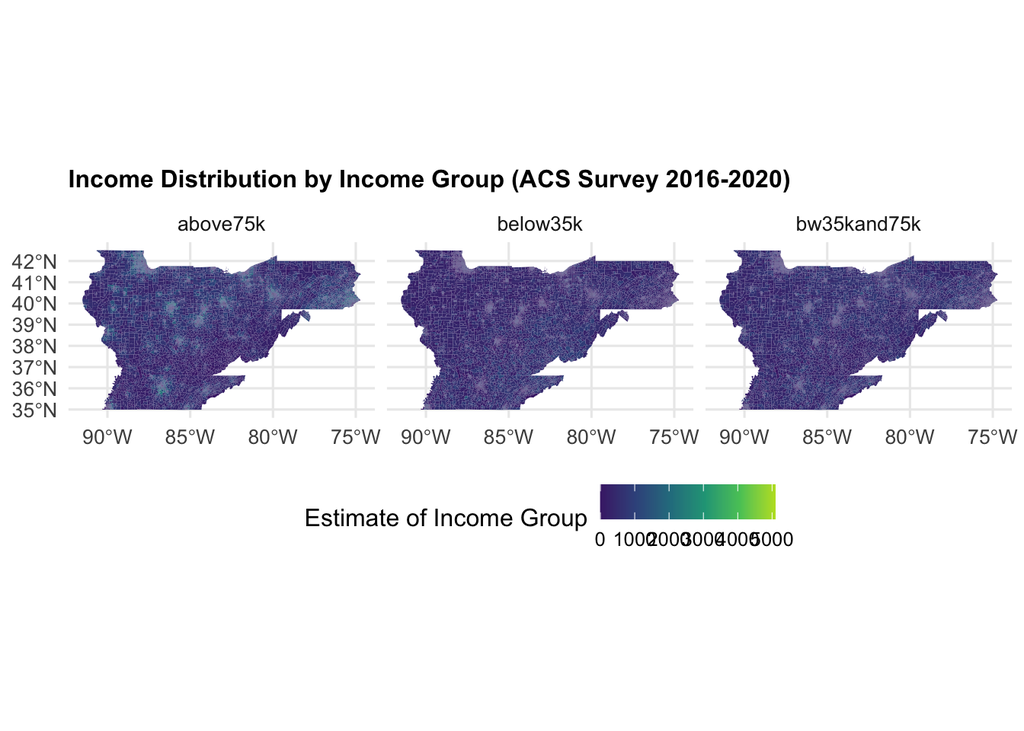

```r
# Plot the geometry of Block Groups with income data by state
ACS_income_data_plot <- ACS_income_data %>%
  ggplot() +
  geom_sf(aes(fill = estimate), color = NA, size = 0.1) +  # Added white border around polygons and mapped income data
  facet_wrap(~ incgroup) +  # Facet by income group
  scale_fill_viridis_c(option = "D", begin = 0.1, end = 0.9) +  # Enhanced viridis color palette for better contrast
  theme_minimal(base_size = 12) +  # Increased base font size for readability
  ggtitle("Income Distribution by Income Group (ACS Survey 2016-2020)") +
  theme(
    legend.position = "bottom",
    plot.title = element_text(size = 12, face = "bold"),
    strip.text = element_text(size = 10),  # Improve facet labels
    axis.text = element_text(size = 10)  # Enhance axis text visibility
  ) +
  labs(fill = "Estimate of Income Group")  # Label the color legend

print(ACS_income_data_plot)
```

### ACS Data by Block Group, Census Tract, and County

(2005-2009, 2010-2014, 2015-2019)

```r
# Define the states to analyze
states <- c("IL", "IN", "OH", "KY", "WV", "PA", "TN")

# Define year ranges and corresponding ACS survey periods
year_ranges <- c(2009, 2014, 2019)
survey_periods <- c("2005-2009", "2010-2014", "2015-2019")
acs_svy <- "acs5"  # ACS 5-year survey, change as needed
acs_geo <- "block group"  # Geography level for block groups

# Define the racial demographic variables from the ACS dataset
race_vars <- c(
  White = "B03002_003",
  Black = "B03002_004",
  Native = "B03002_005",
  Asian = "B03002_006",
  HIPI = "B03002_007",
  Hispanic = "B03002_012"
)

# Function to download and process data for a given state, year, and geography level
get_state_race_data <- function(state, acs_year = 2009, acs_geo = "block group") {
  tryCatch({
    get_acs(
      geography = acs_geo,
      survey = acs_svy,
      year = acs_year,
      state = state,
      variables = race_vars,
      summary_var = "B03002_001"
    ) %>%
      clean_names() %>%
      mutate(percent = 100 * (estimate / summary_est)) %>%
      select(geoid, name, variable, percent)
  }, error = function(e) {
    message(paste("Error in downloading data for", state, "in", acs_year))
    return(NULL)
  })
}

# Create an empty list to store the results for Census Tract level
all_race_data_tract <- list()

# Loop over the year ranges and ACS survey periods for Census Tract
for (i in 1:length(year_ranges)) {
  acs_year <- year_ranges[i]
  acs_survey_period <- survey_periods[i]

  # Apply the function to each state and combine the results
  state_race_data_tract <- purrr::map_dfr(states, ~get_state_race_data(.x, acs_year = acs_year, acs_geo = "block group"))

  # Add the ACS survey period to the dataset
  if (!is.null(state_race_data_tract)) {
    all_race_data_tract[[i]] <- state_race_data_tract %>%
      mutate(ACS_survey = acs_survey_period)
  }
}

# Combine all datasets into one for Block Group level
ACS5_population_race_block_group <- bind_rows(all_race_data_tract)

# Define the output path and filename for Block Group
output_path_block_group <- here("Output", "Sheets", "ACS5_population_racial_demography_block_group_2005_2019.csv")

# Save the resulting dataset to a CSV file in the specified location for Block Group
write.csv(ACS5_population_race_block_group, file = output_path_block_group, row.names = FALSE)

# View a summary of the resulting dataset for Block Group
glimpse(ACS5_population_race_block_group)
```

[output not shown]

```r
# Define the states to analyze and set relevant parameters
states <- c("IL", "IN", "OH", "KY", "WV", "PA", "TN")

# Define year ranges and corresponding ACS survey periods
year_ranges <- c(2009, 2014, 2019)
survey_periods <- c("2005-2009", "2010-2014", "2015-2019")
acs_svy <- "acs5"  # ACS 5-year survey, change as needed

# Define the racial demographic variables from the ACS dataset
race_vars <- c(
  White = "B03002_003",
  Black = "B03002_004",
  Native = "B03002_005",
  Asian = "B03002_006",
  HIPI = "B03002_007",
  Hispanic = "B03002_012"
)

# Function to download and process data for a given state, year, and geography level
get_state_race_data <- function(state, acs_year = 2009, acs_geo = "tract") {
  tryCatch({
    get_acs(
      geography = acs_geo,
      survey = acs_svy,
      year = acs_year,
      state = state,
      variables = race_vars,
      summary_var = "B03002_001"
    ) %>%
      clean_names() %>%
      mutate(percent = 100 * (estimate / summary_est)) %>%
      select(geoid, name, variable, percent)
  }, error = function(e) {
    message(paste("Error in downloading data for", state, "in", acs_year))
    return(NULL)
  })
}

# Create an empty list to store the results for Census Tract level
all_race_data_tract <- list()

# Loop over the year ranges and ACS survey periods for Census Tract
for (i in 1:length(year_ranges)) {
  acs_year <- year_ranges[i]
  acs_survey_period <- survey_periods[i]

  # Apply the function to each state and combine the results
  state_race_data_tract <- purrr::map_dfr(states, ~get_state_race_data(.x, acs_year = acs_year, acs_geo = "tract"))

  # Add the ACS survey period to the dataset
  if (!is.null(state_race_data_tract)) {
    all_race_data_tract[[i]] <- state_race_data_tract %>%
      mutate(ACS_survey = acs_survey_period)
  }
}

# Combine all datasets into one for Census Tract level
ACS5_population_race_tract <- bind_rows(all_race_data_tract)

# Define the output path and filename for Census Tract
output_path_tract <- here("Output", "Sheets", "ACS5_population_racial_demography_tract_2005_2019.csv")

# Save the resulting dataset to a CSV file in the specified location for Census Tract
write.csv(ACS5_population_race_tract, file = output_path_tract, row.names = FALSE)

# View a summary of the resulting dataset for Census Tract
glimpse(ACS5_population_race_tract)
```

```
## Rows: 245,862
## Columns: 5
## $ geoid      <chr> "17001000100", "17001000100", "17001000100", "17001000100",…
## $ name       <chr> "Census Tract 1, Adams County, Illinois", "Census Tract 1, …
## $ variable   <chr> "White", "Black", "Native", "Asian", "HIPI", "Hispanic", "W…
## $ percent    <dbl> 96.7053, 0.0000, 0.7124, 0.0000, 0.0000, 1.4470, 91.1659, 6…
## $ ACS_survey <chr> "2005-2009", "2005-2009", "2005-2009", "2005-2009", "2005-2…
```

```r
# Define the states to analyze and set relevant parameters
states <- c("IL", "IN", "OH", "KY", "WV", "PA", "TN")

# Define year ranges and corresponding ACS survey periods
year_ranges <- c(2009, 2014, 2019)
survey_periods <- c("2005-2009", "2010-2014", "2015-2019")
acs_svy <- "acs5"  # ACS 5-year survey, change as needed

# Define the racial demographic variables from the ACS dataset
race_vars <- c(
  White = "B03002_003",
  Black = "B03002_004",
  Native = "B03002_005",
  Asian = "B03002_006",
  HIPI = "B03002_007",
  Hispanic = "B03002_012"
)

# Function to download and process data for County level (change geography)
get_state_race_data_county <- function(state, acs_year = 2009, acs_geo = "county") {
  tryCatch({
    get_acs(
      geography = acs_geo,
      survey = acs_svy,
      year = acs_year,
      state = state,
      variables = race_vars,
      summary_var = "B03002_001"
    ) %>%
      clean_names() %>%
      mutate(percent = 100 * (estimate / summary_est)) %>%
      select(geoid, name, variable, percent)
  }, error = function(e) {
    message(paste("Error in downloading data for", state, "in", acs_year))
    return(NULL)
  })
}

# Create an empty list to store the results for County level
all_race_data_county <- list()

# Loop over the year ranges and ACS survey periods for County
for (i in 1:length(year_ranges)) {
  acs_year <- year_ranges[i]
  acs_survey_period <- survey_periods[i]

  # Apply the function to each state and combine the results
  state_race_data_county <- purrr::map_dfr(states, ~get_state_race_data_county(.x, acs_year = acs_year, acs_geo = "county"))

  # Add the ACS survey period to the dataset
  if (!is.null(state_race_data_county)) {
    all_race_data_county[[i]] <- state_race_data_county %>%
      mutate(ACS_survey = acs_survey_period)
  }
}

# Combine all datasets into one for County level
ACS5_population_race_county <- bind_rows(all_race_data_county)

# Define the output path and filename for County level
output_path_county <- here("Output", "Sheets", "ACS5_population_racial_demography_county_2005_2019.csv")

# Save the resulting dataset to a CSV file in the specified location for County
write.csv(ACS5_population_race_county, file = output_path_county, row.names = FALSE)

# View a summary of the resulting dataset for County
glimpse(ACS5_population_race_county)
```

```
## Rows: 11,142
## Columns: 5
## $ geoid      <chr> "17001", "17001", "17001", "17001", "17001", "17001", "1700…
## $ name       <chr> "Adams County, Illinois", "Adams County, Illinois", "Adams …
## $ variable   <chr> "White", "Black", "Native", "Asian", "HIPI", "Hispanic", "W…
## $ percent    <dbl> 93.98732, 3.15434, 0.11661, 0.53519, 0.00000, 0.93883, 63.0…
## $ ACS_survey <chr> "2005-2009", "2005-2009", "2005-2009", "2005-2009", "2005-2…
```

## Downloading Decenial Census Data

This section retrieves Decennial Census Data for various states from the 2020 Census. It focuses on racial and ethnic categories among adults age 18+.

### Exploring Variables

```r
#### Check variable names (correct programs)
vars_2020 <- tidycensus::load_variables(2020, "pl",  cache = TRUE)
vars_2010 <- tidycensus::load_variables(2010, "sf1", cache = TRUE)
vars_2000 <- tidycensus::load_variables(2000, "sf1", cache = TRUE)

# quick peek
dplyr::glimpse(vars_2020)
```

```
## Rows: 301
## Columns: 3
## $ name    <chr> "H1_001N", "H1_002N", "H1_003N", "P1_001N", "P1_002N", "P1_003…
## $ label   <chr> " !!Total:", " !!Total:!!Occupied", " !!Total:!!Vacant", " !!T…
## $ concept <chr> "OCCUPANCY STATUS", "OCCUPANCY STATUS", "OCCUPANCY STATUS", "R…
```

```r
dplyr::glimpse(vars_2010)
```

```
## Rows: 8,959
## Columns: 3
## $ name    <chr> "H001001", "H002001", "H002002", "H002003", "H002004", "H00200…
## $ label   <chr> "Total", "Total", "Total!!Urban", "Total!!Urban!!Inside urbani…
## $ concept <chr> "HOUSING UNITS", "URBAN AND RURAL", "URBAN AND RURAL", "URBAN …
```

```r
dplyr::glimpse(vars_2000)
```

```
## Rows: 8,113
## Columns: 3
## $ name    <chr> "H001001", "H002001", "H002002", "H002003", "H002004", "H00200…
## $ label   <chr> "Total", "Total", "Total!!Urban", "Total!!Urban!!Inside urbani…
## $ concept <chr> "HOUSING UNITS [1]", "URBAN AND RURAL [6]", "URBAN AND RURAL […
```

### Decennial Census Data (2020)

```r
# Define the states of interest and the variables to query
states <- c("IL", "IN", "OH", "KY", "WV", "PA", "TN")  # Target states
sdiv   <- function(num, den) ifelse(den > 0, num/den, NA_real_)

# Variables for the 2020 Decennial Census
variables_2020 <- c(
  adult18_total = "P4_001N",  # Total 18+
  adult18_hisp  = "P4_002N",  # Hispanic (any race) 18+
  adult18_nhw   = "P4_005N",  # Not Hispanic: White alone 18+
  adult18_nhb   = "P4_006N"   # Not Hispanic: Black alone 18+
)

CENSUS_2020_bg <- purrr::map_dfr(states, ~ get_decennial(
  geography     = "block group",
  year          = 2020,
  sumfile       = "pl",
  state         = .x,
  variables     = variables_2020,
  geometry      = TRUE,
  keep_geo_vars = TRUE,
  output        = "wide"
)) %>%
  janitor::clean_names() %>%
  sf::st_make_valid() %>%
  dplyr::filter(!sf::st_is_empty(geometry)) %>%
  sf::st_transform(4326) %>%
  dplyr::mutate(
    percent_hispanic_18plus         = sdiv(adult18_hisp, adult18_total),
    percent_nonhisp_white_18plus    = sdiv(adult18_nhw,  adult18_total),
    percent_nonhisp_black_18plus    = sdiv(adult18_nhb,  adult18_total)
  )

# quick peek
CENSUS_2020_bg %>% st_drop_geometry() %>% head()
```

```
## # A tibble: 6 × 19
##   statefp countyfp tractce blkgrpce affgeoid  geoid name_x namelsad lsad   aland
##   <chr>   <chr>    <chr>   <chr>    <chr>     <chr> <chr>  <chr>    <chr>  <dbl>
## 1 17      097      864308  3        1500000U… 1709… 3      Block G… BG    7.55e6
## 2 17      031      833100  1        1500000U… 1703… 1      Block G… BG    2.78e5
## 3 17      097      861011  4        1500000U… 1709… 4      Block G… BG    8.04e5
## 4 17      089      852101  3        1500000U… 1708… 3      Block G… BG    4.57e6
## 5 17      161      020800  1        1500000U… 1716… 1      Block G… BG    1.03e6
## 6 17      031      830500  3        1500000U… 1703… 3      Block G… BG    1.59e6
## # ℹ 9 more variables: awater <dbl>, name_y <chr>, adult18_total <dbl>,
## #   adult18_hisp <dbl>, adult18_nhw <dbl>, adult18_nhb <dbl>,
## #   percent_hispanic_18plus <dbl>, percent_nonhisp_white_18plus <dbl>,
## #   percent_nonhisp_black_18plus <dbl>
```

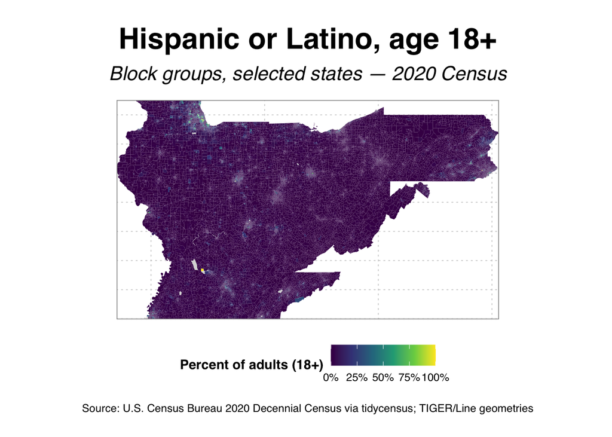

```r
theme_du_bois <- function() {
  theme_minimal(base_family = "sans", base_size = 12) %+replace%
    theme(
      # warm off‐white paper tone
      plot.background   = element_rect(fill = NA, colour = NA),
      panel.background  = element_rect(fill = NA, colour = NA),
      # subtle dotted grid reminiscent of period illustrations
      panel.grid.major  = element_line(colour = "grey80", linetype = "dotted", size = 0.3),
      panel.grid.minor  = element_blank(),
      # a thin “frame” around the map
      panel.border      = element_rect(colour = "grey60", fill = NA, size = 0.6),
      # remove axes
      axis.text         = element_blank(),
      axis.ticks        = element_blank(),
      axis.title        = element_blank(),
      # titles in sturdy sans
      plot.title        = element_text(
        family = "sans", face = "bold", size = 24,
        hjust = 0.5, margin = margin(b = 10)
      ),
      plot.subtitle     = element_text(
        family = "sans", face = "italic", size = 16,
        hjust = 0.5, margin = margin(b = 15)
      ),
      # small sans caption, centered
      plot.caption      = element_text(
        family = "sans", size = 9, hjust = 0.5,
        margin = margin(t = 10)
      ),
      # legend at bottom, with clear keys
      legend.position   = "bottom",
      legend.title      = element_text(family = "sans", face = "bold", size = 11),
      legend.text       = element_text(family = "sans", size = 9),
      legend.key        = element_rect(fill = NA, colour = NA),
      legend.background = element_rect(fill = "transparent", colour = NA),
      # generous plot margins
      plot.margin       = margin(20, 20, 20, 20)
    )
}

# Use the same 0–1 percent scale but relabel legend for 18+
scale_pct_18plus <- function() {
  ggplot2::scale_fill_viridis_c(
    limits   = c(0, 1),
    oob      = scales::squish,
    labels   = scales::percent_format(accuracy = 1),
    na.value = "grey85",
    name     = "Percent of adults (18+)"
  )
}

# Common bounding box (regionwide view)
bb <- sf::st_bbox(CENSUS_2020_bg)

# --- Map 1: Hispanic or Latino, age 18+ (any race) ---
p_hisp18 <- ggplot2::ggplot(CENSUS_2020_bg) +
  ggplot2::geom_sf(ggplot2::aes(fill = percent_hispanic_18plus), color = NA) +
  scale_pct_18plus() +
  ggplot2::coord_sf(
    xlim = c(bb["xmin"], bb["xmax"]),
    ylim = c(bb["ymin"], bb["ymax"]),
    expand = FALSE
  ) +
  ggplot2::labs(
    title    = "Hispanic or Latino, age 18+",
    subtitle = "Block groups, selected states — 2020 Census",
    caption  = "Source: U.S. Census Bureau 2020 Decennial Census via tidycensus; TIGER/Line geometries"
  ) +
  theme_du_bois()
print(p_hisp18)
```

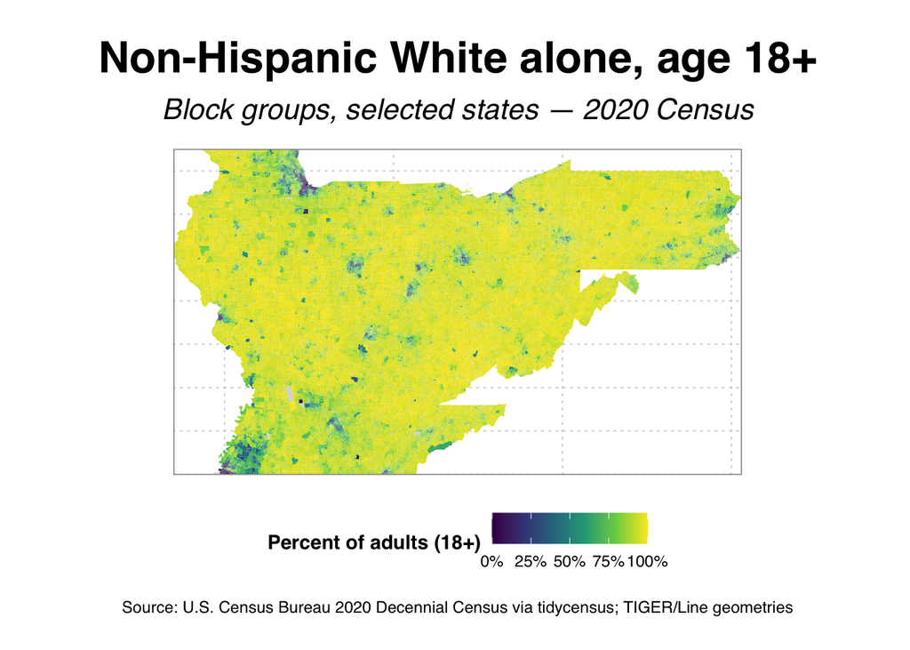

```r
ggplot2::ggsave(
  filename = here::here(out_dir, "CENSUS_2020_percent_hispanic.png"),
  plot = p_hisp18, width = 10, height = 8, dpi = 600
)

# --- Map 2: Non-Hispanic White alone, age 18+ ---
p_nhw18 <- ggplot2::ggplot(CENSUS_2020_bg) +
  ggplot2::geom_sf(ggplot2::aes(fill = percent_nonhisp_white_18plus), color = NA) +
  scale_pct_18plus() +
  ggplot2::coord_sf(
    xlim = c(bb["xmin"], bb["xmax"]),
    ylim = c(bb["ymin"], bb["ymax"]),
    expand = FALSE
  ) +
  ggplot2::labs(
    title    = "Non-Hispanic White alone, age 18+",
    subtitle = "Block groups, selected states — 2020 Census",
    caption  = "Source: U.S. Census Bureau 2020 Decennial Census via tidycensus; TIGER/Line geometries"
  ) +
  theme_du_bois()
print(p_nhw18)
```

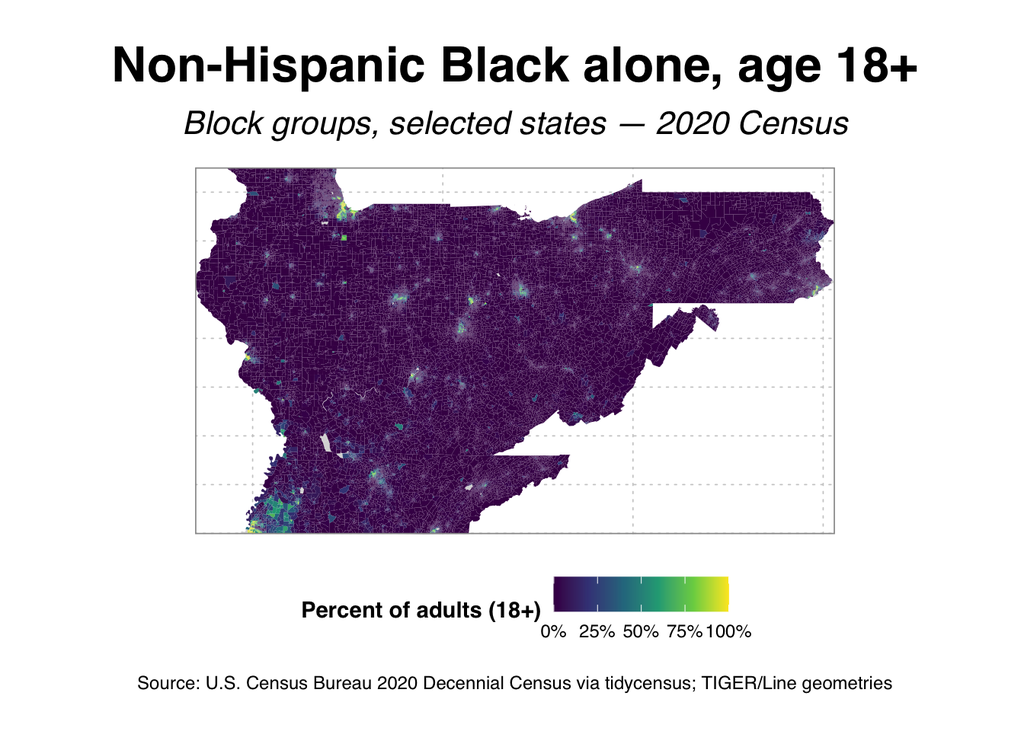

```r
ggplot2::ggsave(
  filename = here::here(out_dir, "CENSUS_2020_percent_nonhisp_white.png"),
  plot = p_nhw18, width = 10, height = 8, dpi = 600
)

# --- Map 3: Non-Hispanic Black alone, age 18+ ---
p_nhb18 <- ggplot2::ggplot(CENSUS_2020_bg) +
  ggplot2::geom_sf(ggplot2::aes(fill = percent_nonhisp_black_18plus), color = NA) +
  scale_pct_18plus() +
  ggplot2::coord_sf(
    xlim = c(bb["xmin"], bb["xmax"]),
    ylim = c(bb["ymin"], bb["ymax"]),
    expand = FALSE
  ) +
  ggplot2::labs(
    title    = "Non-Hispanic Black alone, age 18+",
    subtitle = "Block groups, selected states — 2020 Census",
    caption  = "Source: U.S. Census Bureau 2020 Decennial Census via tidycensus; TIGER/Line geometries"
  ) +
  theme_du_bois()
print(p_nhb18)
```

```r
ggplot2::ggsave(
  filename = here::here(out_dir, "CENSUS_2020_percent_nonhisp_black.png"),
  plot = p_nhb18, width = 10, height = 8, dpi = 600
)
```

# Citations

Walker, K., & Tufford, L. (2017). tidycensus: An R package for downloading and processing U.S. Census data. Journal of Statistical Software, 83(7), 1–11. https://doi.org/10.18637/jss.v083.i07

U.S. Census Bureau. (2020). American Community Survey (ACS). U.S. Census Bureau. Retrieved from https://www.census.gov/programs-surveys/acs/

U.S. Census Bureau. (2020). Decennial Census - PL94-171 Summary File. U.S. Census Bureau. Retrieved from https://www.census.gov/data/tables/time-series/demo/popest/2020s-counties.html